# Lab 7

## Using Multiple Features to Optimize Cuts

### Mass and EE2

```python
def getTwoCuts(s_list1,s_list2,s_cut1,s_cut2):
    s_comb1 = [[],[]]
    s_comb2 = [[],[]]
    s_higgs1 = []
    s_qcd1 = []
    s_higgs2 = []
    s_qcd2 = []
    for i in range(0,len(higgsDF[s_list1])):
        if s_cut1[0] <= higgsDF[s_list1][i] and higgsDF[s_list1][i] < s_cut1[1]:
            s_higgs1.append(i)
    for i in range(0,len(qcdDF[s_list1])):
        if s_cut1[0] <= qcdDF[s_list1][i] and qcdDF[s_list1][i] < s_cut1[1]:
            s_qcd1.append(i)
    for i in range(0,len(higgsDF[s_list2])):
        if s_cut2[0] <= higgsDF[s_list2][i] and higgsDF[s_list2][i] < s_cut2[1]:
            s_higgs2.append(i)
    for i in range(0,len(qcdDF[s_list2])):
        if s_cut2[0] <= qcdDF[s_list2][i] and qcdDF[s_list2][i] < s_cut2[1]:
            s_qcd2.append(i)

    for i in s_higgs1:
        if i in s_higgs2:
            s_comb1[0].append(higgsDF[s_list1][i])
            s_comb2[0].append(higgsDF[s_list2][i])
    for i in s_qcd1:
        if i in s_qcd2:
            s_comb1[1].append(qcdDF[s_list1][i])
            s_comb2[1].append(qcdDF[s_list2][i])
    return s_comb1,s_comb2
```

```python
# This is its own cell since it takes a while to run
s_comb1,s_comb2 = getTwoCuts("mass","ee2",[120,130],[0.05,0.07])
```

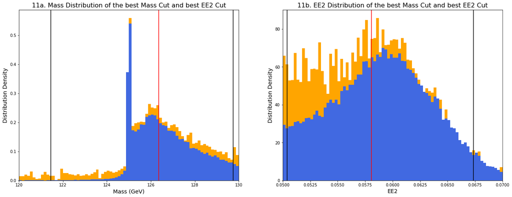

```
Expected Mass of Cut = 126.364 GeV
Expected EE2 of Cut = 0.058
Ratio of Higgs to Sqrt QCD Jets = 10.823
```

```python
fig,ax = plt.subplots(1,2)
plt.subplot(1,2,1)
bins = np.linspace(120,130,81)
listS = s_comb1 # Mass List Stacked
listW = [np.ones(len(listS[0])) * 50, np.ones(len(listS[1])) * 2000] # Mass List Weights
plt.hist(listS,bins,stacked=True,density=True,weights=listW,color=["RoyalBlue","Orange"])
plt.xlim([120,130])
plt.title("11a. Mass Distribution of the best Mass Cut and best EE2 Cut",fontsize=16)
plt.xlabel("Mass (GeV)",fontsize=14)
plt.ylabel("Distribution Density",fontsize=14)
s1_M,s1_L,s1_R,s1_N = getSignificance(s_comb1,None)
plt.axvline(x=s1_M,color="Red")
plt.axvline(x=s1_L,color="Black")
plt.axvline(x=s1_R,color="Black")
n_ratio1 = s1_N[0] / math.sqrt(s1_N[1])

plt.subplot(1,2,2)
bins = np.linspace(0.05,0.07,81)
listS = s_comb2 # Mass List Stacked
listW = [np.ones(len(listS[0])) * 50, np.ones(len(listS[1])) * 2000] # Mass List Weights
plt.hist(listS,bins,stacked=True,density=True,weights=listW,color=["RoyalBlue","Orange"])
plt.xlim([0.05,0.07])
plt.title("11b. EE2 Distribution of the best Mass Cut and best EE2 Cut",fontsize=16)
plt.xlabel("EE2",fontsize=14)
plt.ylabel("Distribution Density",fontsize=14)
s2_M,s2_L,s2_R,s2_N = getSignificance(s_comb2,None)
plt.axvline(x=s2_M,color="Red")
plt.axvline(x=s2_L,color="Black")
plt.axvline(x=s2_R,color="Black")
n_ratio2 = s2_N[0] / math.sqrt(s2_N[1])

plt.show()
n_ratio = max(n_ratio1,n_ratio2)
print("Expected Mass of Cut = " + str(np.round(s1_M,3)) + " GeV")
print("Expected EE2 of Cut = " + str(np.round(s2_M,3)))
print("Ratio of Higgs to Sqrt QCD Jets = " + str(np.round(n_ratio,3)))
```

Once I combined the the best cuts of the two best discriminating features, mass and EE2, the n ratio skyrocketed up to 10.823. Moreover, you easily see how the Higgs jets now dominate the distributions in figures 11a and 11b.

### EE2 and D2

```python
# This is its own cell since it takes a while to run
s_comb1,s_comb2 = getTwoCuts("ee2","d2",[0.05,0.07],[0,2])
```

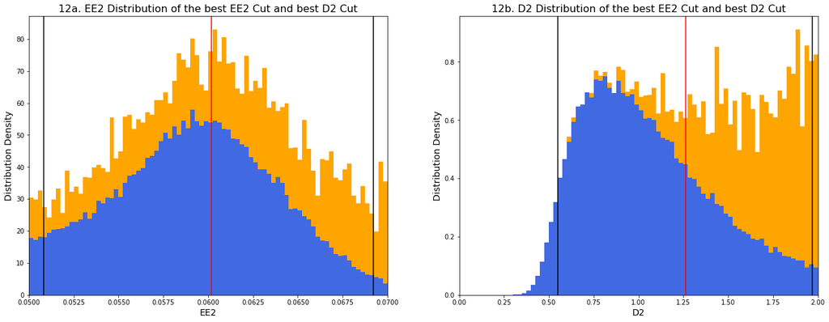

```
Expected EE2 of Cut = 0.06
Expected D2 of Cut = 1.262
Ratio of Higgs to Sqrt QCD Jets = 7.398
```

```python
fig,ax = plt.subplots(1,2)
plt.subplot(1,2,1)
bins = np.linspace(0.05,0.07,81)
listS = s_comb1 # Mass List Stacked
listW = [np.ones(len(listS[0])) * 50, np.ones(len(listS[1])) * 2000] # Mass List Weights
plt.hist(listS,bins,stacked=True,density=True,weights=listW,color=["RoyalBlue","Orange"])
plt.xlim([0.05,0.07])
plt.title("12a. EE2 Distribution of the best EE2 Cut and best D2 Cut",fontsize=16)
plt.xlabel("EE2",fontsize=14)
plt.ylabel("Distribution Density",fontsize=14)
s1_M,s1_L,s1_R,s1_N = getSignificance(s_comb1,None)
plt.axvline(x=s1_M,color="Red")
plt.axvline(x=s1_L,color="Black")
plt.axvline(x=s1_R,color="Black")
n_ratio1 = s1_N[0] / math.sqrt(s1_N[1])

plt.subplot(1,2,2)
bins = np.linspace(0,2,81)
listS = s_comb2 # Mass List Stacked
listW = [np.ones(len(listS[0])) * 50, np.ones(len(listS[1])) * 2000] # Mass List Weights
plt.hist(listS,bins,stacked=True,density=True,weights=listW,color=["RoyalBlue","Orange"])
plt.xlim([0,2])
plt.title("12b. D2 Distribution of the best EE2 Cut and best D2 Cut",fontsize=16)
plt.xlabel("D2",fontsize=14)
plt.ylabel("Distribution Density",fontsize=14)
s2_M,s2_L,s2_R,s2_N = getSignificance(s_comb2,None)
plt.axvline(x=s2_M,color="Red")
plt.axvline(x=s2_L,color="Black")
plt.axvline(x=s2_R,color="Black")
n_ratio2 = s2_N[0] / math.sqrt(s2_N[1])

plt.show()
n_ratio = max(n_ratio1,n_ratio2)
print("Expected EE2 of Cut = " + str(np.round(s1_M,3)))
print("Expected D2 of Cut = " + str(np.round(s2_M,3)))
print("Ratio of Higgs to Sqrt QCD Jets = " + str(np.round(n_ratio,3)))
```

While not as incredible as the mass and EE2 combined cuts, it's worth noting that there're absolutely no QCD jets in the range of 0.25 to 0.55, which would suggest that a tighter cut in D2 would result in a better n ratio.